# Supplyment to: Sedimentary basins reduce stability of Antarctic ice streams through groundwater feedbacks

Lu Li$^1$, Alan R.A. Aitken$^1$$^,$$^2$, Mark D. Lindsay$^1$$^,$$^3$$^,$$^4$, Bernd Kulessa$^5$$^,$$^6$ $^1$School of Earth Sciences, The University Of Western Australia, Perth, Western Australia, 6009, Australia $^2$The Australian Centre for Excellence in Antarctic Science, The University of Western Australia, Perth, Western Australia, 6009, Australia $^3$CSIRO Mineral Resources, Perth, Western Australia, 6151, Australia $^4$ARC Industrial Transformation and Training Centre in Data Analytics for Resources and the Environment (DARE) $^5$School of Biosciences, Geography and Physics, Swansea University, Wales, SA2 8PP, UK $^6$School of Geography, Planning, and Spatial Sciences, University of Tasmania, Hobart, Tasmania, 7001, Australia

# Introduction

A map of subglacial sedimentary basin distribution of Antarctica is driven from the current understanding of Antarctica bedrock geology and continental scale geophysical datasets. The training points are generated by sparse bedrock outcrop, seismic imaging, and geophysical interpretation. Input features include continental scale topography, gravity, magnetic, and their derivative products.

# Preparation

## Load required R packages

The required R pacages are loaded.

```r
suppressPackageStartupMessages({
library(geosphere)
library(sdmpredictors)
library(randomForest)
library(summarytools)
library(Boruta)
library(caret)
library(raster)
library(ggplot2)
library(GGally)
library(rgdal)
library(corrplot)
library(blockCV)
library(measures)
library(reticulate)
library(readr)
library(missForest)
library(sf)
library(Hmisc)
library(gapfill)
library(colorRamps)
library(scico)
library(MLeval)
library(precrec)
library(rgeos)
library(VIM)
library(mice)
library(minerva)
library(ggpubr)
library(viridis)
library(fields)
library(reshape)

})
```

## Define function to train the model

```r
sample_training <- function(Train,Input_feature,fishgrid,mtry,ntree,ns,nk,seed) {

rgeos::set_RGEOS_CheckValidity(2L)


Train_Basement <- subset(Train, Label == 0)

Train_SSB <- subset(Train, Label == 1)

Train_Basement_M <- aggregate(Train_Basement,dissolve=T)

Train_SSB_M <- aggregate(Train_SSB,dissolve=T)

Train_Basement_M_C <- gIntersection(Train_Basement_M, fishgrid, byid = TRUE, drop_lower_td = T)

Train_SSB_M_C <- gIntersection(Train_SSB_M, fishgrid, byid = TRUE, drop_lower_td = T)

Train_Basement.sp <- SpatialPolygonsDataFrame(Train_Basement_M_C, data.frame(N = c(1:length(Train_Basement_M_C))), match.ID = F)

Train_SSB.sp <- SpatialPolygonsDataFrame(Train_SSB_M_C, data.frame(N = c(1:length(Train_SSB_M_C))), match.ID = F)


prob.all <- stack()

fres.all <- stack()

Model_Validation <- list()

T.all <- list()

bcv.all <- data.frame()

bcv.acc <- list()

for (k in 1:nk) {

set.seed(seed[k]) #Set seed for reproducibility


T_base <- list()

T_basin <- list()


for (i in unique(Train_Basement.sp$N)) {
        HR <- Train_Basement.sp[Train_Basement.sp$N==i,]
        T_base[[i]] <- spsample(HR, n = ns, "random",iter=10)
}


for (i in unique(Train_SSB.sp$N)) {
        HR <- Train_SSB.sp[Train_SSB.sp$N==i,]
        T_basin[[i]] <- spsample(HR, n = ns, "random",iter=10)
}

Tbase <- do.call("rbind", T_base)
Tbasin <- do.call("rbind", T_basin)


# Label training points
Tbase$Label <- c(1:length(Tbase))

Tbase$Label <- 0

Tbasin$Label <- c(1:length(Tbasin))

Tbasin$Label <- 1

TB <- rbind(Tbase,Tbasin)


# Extract Input feature (evidence) into Training Point

sdata <- data.frame(TB,extract(Input_feature,TB))

sdata <- sdata[-c(4)]

names(sdata)[2] <- "x"

names(sdata)[3] <- "y"



sdata <- na.omit(sdata) #drop nan value

data_min <- min(table(sdata$Label))

#data_min <- min(data_min,613)


sub_0 <- sample( nrow(subset(sdata, Label == 0 )), data_min)
sub_1 <- sample( nrow(subset(sdata, Label == 1 )), data_min)

sdata_s_0 <- subset(sdata, Label == 0 )[sub_0, ]
sdata_s_1 <- subset(sdata, Label == 1 )[sub_1, ]

sdata <- rbind(sdata_s_0,sdata_s_1)


if (k==1) {
TPSummary <- data.frame(sdata[1:3])
} else {
TPSummary <- data.frame(TPSummary,sdata[1:3])
}



TP <- st_as_sf(sdata, coords = c("x", "y"), crs = 3031)

TP.s <- as(TP, "Spatial")

tp_nb <- st_set_geometry(TP, NULL) #remove geometry

tp_ngeo <- tp_nb

tp_in <- na.omit(tp_ngeo) #drop nan value


#Fit a model


tp_in$Label <- as.factor(tp_in$Label)


fit <- randomForest(Label ~ ., data=tp_in, ntree=ntree, mtry=mtry, replace = T, importance = TRUE,na.action = na.roughfix)


#Variable importance
randomForest::importance(fit, type=1, scale = FALSE) #table

main <- paste("Variable Importance on TP",nk)

I1 <- ++ varImpPlot(fit, type=1, scale = FALSE) #plot

if (k==1) {
I2 <- data.frame(I1)
} else {
  I2 <- data.frame(I2,I1)
}


class <- c("0","1")

classes <- c("Basement","SSB")


#Predicted probabilities

rfprob <- predict(Input_feature, fit, type="prob", index=class)




names(rfprob) <- classes

prob.all <- stack(prob.all,rfprob$SSB)

max.prob <- max(rfprob)
max.prob

rfres <- predict(Input_feature, fit, type="response")

fres.all <- stack(fres.all,rfres)


levels(tp_in$Label) <- c("Basement", "SSB")




pred_T <- predict(fit, tp_in, type = "response") # predict the test set

Predit_Train <- rbind(data.frame(tp_in[,1], pred_T, sdata[,2:3]))

T.all <- rbind(T.all,Predit_Train)



#Perform Block Cross Validation
block.C2 <- spatialBlock(speciesData = TP, # sf or SpatialPoints
                   species = "Label", # the response column (binomial or multi-class)
                   rows = 10,
                   cols = 10,
                   k = 10, # number of folds
                   selection = "random")

folds <- block.C2$folds

Nclasses <- c(2L)

class <- c("0","1")

classes <- c("Basement","SSB")

# create a data.frame to store the prediction of each fold (record)
testTable <- tp_in
testTable$pred <- NA

t <- data.frame()


for(kk in seq_len(length(folds))){

  # extracting the training and testing indices
  # this way works with folds list (but not foldID)
  trainSet <- unlist(folds[[kk]][1]) # training set indices

  testSet <- unlist(folds[[kk]][2]) # testing set indices

  sub_train <- tp_in[trainSet, ]

  sub_train$Label <- as.factor(sub_train$Label)

  sub_test <- tp_in[testSet, ]

  nnmin <- min(table(sub_train[1]))

  rf <- randomForest(Label~., data=sub_train, replace = T, ntree=ntree, mtry=mtry, na.action = na.roughfix) # model fitting on training set

  pred <- predict(rf, sub_test, type = "response",na.action = na.roughfix) # predict the test set

  t <- rbind(t, data.frame(sub_test[1], pred, sdata[testSet,2:3]))

}


acc <- confusionMatrix(t$pred,as.factor(t$Label))

name <- paste("T", kk, sep = "")

tmp <- list(conf=acc)

bcv.acc[[name]] <- tmp

bcv.all <- rbind(bcv.all,t)



}

Result <- list("TP"=TPSummary,"Probalility" = prob.all,"fress"= fres.all,"importance"=I2,"TPacc"=T.all,"blockCV"=bcv.all,"blockacc"=bcv.acc)

return (Result)
}
```

Sample training points

```r
sampling <- function(Train,Input_feature,fishgrid,ns,nk,seed) {

  rgeos::set_RGEOS_CheckValidity(2L)

for (k in 1:nk) {

  set.seed(seed[k]) #Set seed for reproducibility

Train_Basement <- subset(Train, Label == 0)

Train_SSB <- subset(Train, Label == 1)

Train_Basement_M <- aggregate(Train_Basement,dissolve=T)

Train_SSB_M <- aggregate(Train_SSB,dissolve=T)

Train_Basement_M_C <- gIntersection(Train_Basement_M, fishgrid, byid = TRUE, drop_lower_td = T)

Train_SSB_M_C <- gIntersection(Train_SSB_M, fishgrid, byid = TRUE, drop_lower_td = T)

Train_Basement.sp <- SpatialPolygonsDataFrame(Train_Basement_M_C, data.frame(N = c(1:length(Train_Basement_M_C))), match.ID = F)

Train_SSB.sp <- SpatialPolygonsDataFrame(Train_SSB_M_C, data.frame(N = c(1:length(Train_SSB_M_C))), match.ID = F)


prob.all <- stack()

fres.all <- stack()



T_base <- list()

T_basin <- list()


for (i in unique(Train_Basement.sp$N)) {
        HR <- Train_Basement.sp[Train_Basement.sp$N==i,]
        T_base[[i]] <- spsample(HR, n = ns, "random",iter=10)
}


for (i in unique(Train_SSB.sp$N)) {
        HR <- Train_SSB.sp[Train_SSB.sp$N==i,]
        T_basin[[i]] <- spsample(HR, n = ns, "random",iter=10)
}

Tbase <- do.call("rbind", T_base)
Tbasin <- do.call("rbind", T_basin)


# Label training points
Tbase$Label <- c(1:length(Tbase))

Tbase$Label <- 0

Tbasin$Label <- c(1:length(Tbasin))

Tbasin$Label <- 1

TB <- rbind(Tbase,Tbasin)


# Extract Input features (evidence) into Training Point

sdata <- data.frame(TB,extract(Input_feature,TB))

sdata <- sdata[-c(4)]

names(sdata)[2] <- "x"

names(sdata)[3] <- "y"

data_min <- min(table(sdata$Label))

print(table(sdata$Label))

data_min <- min(data_min,613)


sub_0 <- sample( nrow(subset(sdata, Label == 0 )), data_min)
sub_1 <- sample( nrow(subset(sdata, Label == 1 )), data_min)

sdata_s_0 <- subset(sdata, Label == 0 )[sub_0, ]
sdata_s_1 <- subset(sdata, Label == 1 )[sub_1, ]

sdata <- rbind(sdata_s_0,sdata_s_1)


TP <- st_as_sf(sdata, coords = c("x", "y"), crs = 3031)

TP <- as(TP, "Spatial")

if (k==1) {
TP.s <- TP
} else {
TP.s <- rbind(TP.s,TP)
}

}
return (TP.s)
}
```

## Load shapefiles for mapping

The coastline and major ice catchments are loaded

```r
Coastline <- readOGR(".\\Plot_data\\Coastline_Antarctica_v02.shp")
Basins_IMBIE <- readOGR(".\\Plot_data\\Basins_IMBIE_Antarctica_v02.shp")
crs(Coastline)
```

```
CRS arguments:
 +proj=stere +lat_0=-90 +lat_ts=-71 +lon_0=0 +x_0=0 +y_0=0 +datum=WGS84
+units=m +no_defs
```

```r
crs(Basins_IMBIE)
```

```
CRS arguments:
 +proj=stere +lat_0=-90 +lat_ts=-71 +lon_0=0 +x_0=0 +y_0=0 +datum=WGS84
+units=m +no_defs
```

# Training point

Training points are generated based on bedrock outcrop, seismic imaging, and potential filed data interpretation

## Read the Training Shapefile and the fishnet to subsample training points

```r
Train_poly <- readOGR(".\\Training_data\\SSB_clean.shp")
```

```r
fishgrid <- readOGR(".\\Plot_data\\TP_fish.shp")
fishgrids <- readOGR(".\\Plot_data\\TP_fish_shift.shp")
```

Edit and divide training polygon into sedimentary basin (Label:1) and crystalline rock (Label:0)

```r
Train_select <- Train_poly

#Mask some training outliers
Train_select[Train_poly$Id ==  80] <- 5 #Amendensen Sea
Train_select[Train_poly$Id ==  -110] <- 5 #Volcano
Train_select[Train_poly$Id ==  222] <- 5 #Central High
Train_select[Train_poly$Id ==  -10000] <- 5 #RIS seismic
Train_select[Train_poly$Id ==  125] <- 5 #RIS seismic
Train_select[Train_poly$Id ==  64] <- 0 #RIS seismic
Train_select[Train_poly$Label ==  10] <- 0 #TW SSB
Train_select[Train_select$Label ==2] <-0 #Old SSB



Train_select <- subset(Train_select, Label < 3)

# 0 for basement 1 for SSB
Train_Basement <- subset(Train_select, Label == 0)

Train_SSB <- subset(Train_select, Label == 1)
```

## Plot Training Polygon

Blue for basement, red for sedimentary basin

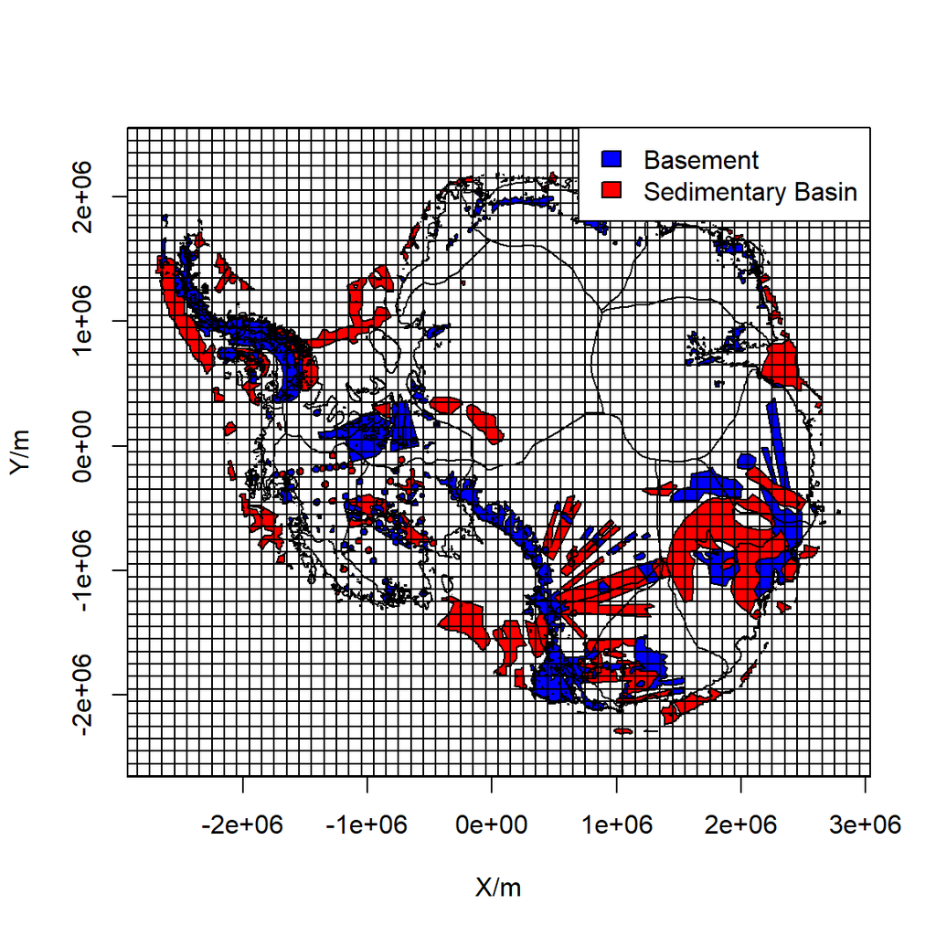

```r
plot(x=NULL,
      y=NULL,
      xlim=c(-2705000, 2815000),  ## with c()
      ylim=c(-2315000, 2215000),xlab="X/m", ylab="Y/m",
      asp=1)  ## with c()
plot(Train_Basement,add=T,col="blue")
plot(Train_SSB,add=T,col="red")
plot(Basins_IMBIE,add=T)

plot(fishgrid,add=T)
legend("topright",
       legend = c('Basement', 'Sedimentary Basin'),
       fill = c("blue","red"),       # Color of the squares
       border = "black") # Color of the border of the squares
```

# Input Features

The input features are generated from avaiLable continental scale geophysical datasets. Including, bedrock topography, gravity, magnetic.

## Read the Input Features

Read input features into a spatial data frame

## Plot Input Features

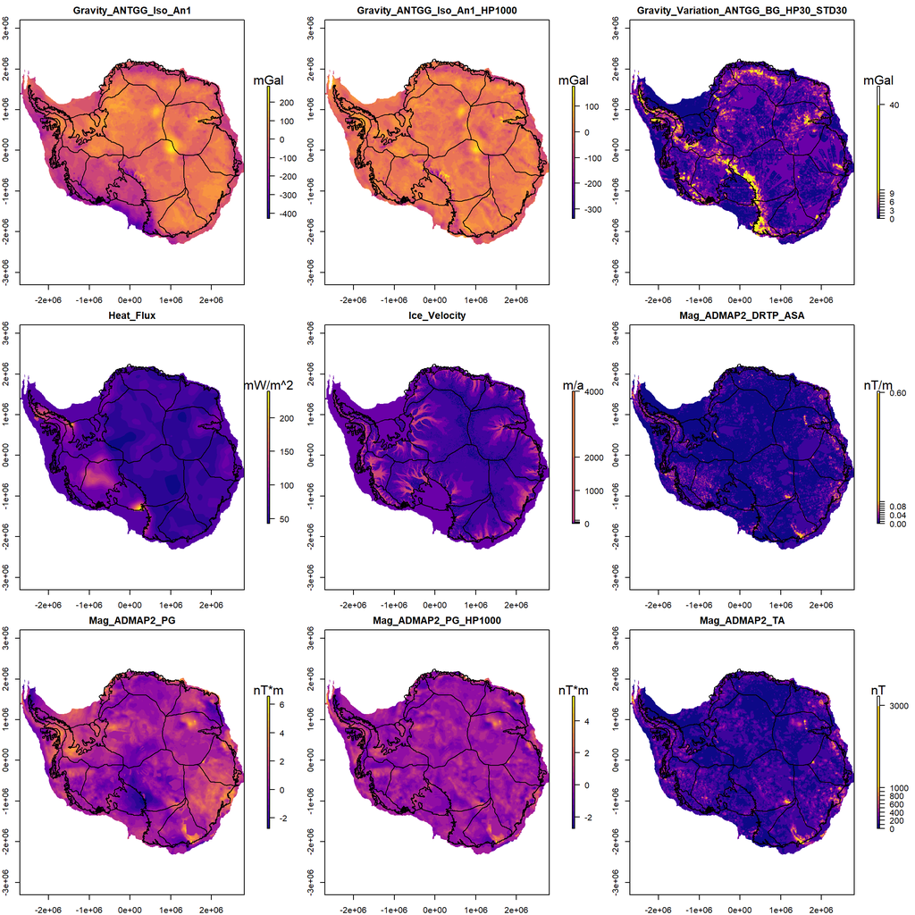

```r
par(mfrow=c(3,3),mar=c(2, 2, 2, 6))    # set the plotting area into a 1*2 array

sel <- subset(Predp.stark,10:18)

le_text=c("mGal","mGal","mGal","mW/m^2","m/a","nT/m","nT*m","nT*m","nT")

for (i in 1:2) {

plot(sel[[i]], col=plasma(21),asp=1,main=names(sel)[i],legend.args =list(text=le_text[i]))
plot(Basins_IMBIE,add=T)
plot(Coastline,add=T)

}

mybreaks <- seq(0, 10, by = 1) #set breaks
mybreaks <- c(mybreaks,40)
plot(sel[[3]], col=plasma(11),breaks=mybreaks, asp=1,main=names(sel)[3],legend.args =list(text=le_text[3]))
plot(Basins_IMBIE,add=T)
plot(Coastline,add=T)

plot(sel[[4]], col=plasma(21),asp=1,main=names(sel)[4],legend.args =list(text=le_text[4]))
plot(Basins_IMBIE,add=T)
plot(Coastline,add=T)



cuts=c(0,1,10,30,50,100,1000,2000,4000) #set breaks
plot(sel[[5]], col=plasma(11),breaks=cuts, asp=1,main=names(sel)[5],legend.args =list(text=le_text[5]))
plot(Basins_IMBIE,add=T)
plot(Coastline,add=T)


mybreaks <- seq(0, 0.1, by = 0.01) #set breaks
mybreaks <- c(mybreaks,0.6)
plot(sel[[6]], col=plasma(12),breaks=mybreaks, asp=1,main=names(sel)[6],legend.args =list(text=le_text[6]))
plot(Basins_IMBIE,add=T)
plot(Coastline,add=T)




for (i in 7:8) {

plot(sel[[i]], col=plasma(21),asp=1,main=names(sel)[i],legend.args =list(text=le_text[i]))
plot(Basins_IMBIE,add=T)
plot(Coastline,add=T)

}

mybreaks <- seq(0, 1000, by = 100) #set breaks
mybreaks <- c(mybreaks,3000)
plot(sel[[9]], col=plasma(12),breaks=mybreaks, asp=1,main=names(sel)[9],legend.args =list(text=le_text[9]))
plot(Basins_IMBIE,add=T)
plot(Coastline,add=T)
```

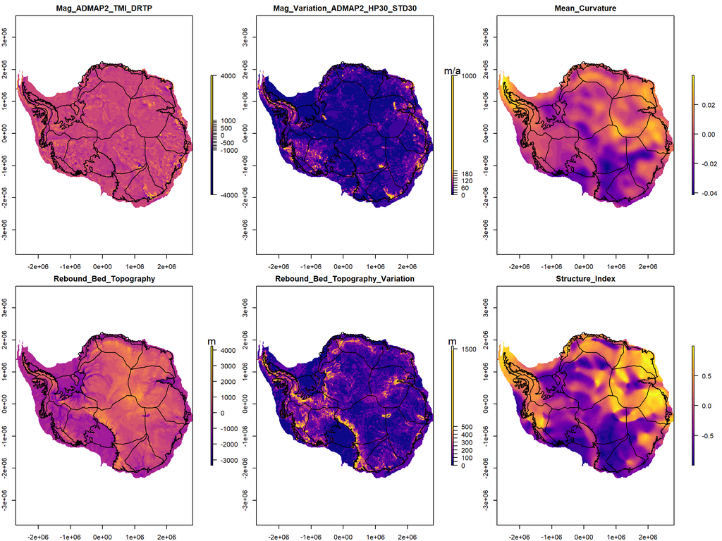

```r
par(mfrow=c(2,3),mar=c(2, 2, 2, 6))    # set the plotting area into a 1*2 array

sel <- subset(Predp.stark,19:length(fs))

le_text=c("mW/m^2","m/a","","m","m","")

mybreaks <- seq(-1000, 1000, by = 100) #set breaks
mybreaks <- c(-4000,mybreaks,4000)
plot(sel[[1]], col=plasma(23),breaks=mybreaks, asp=1,main=names(sel)[1],legend.args =list(text=le_text[12]))
plot(Basins_IMBIE,add=T)
plot(Coastline,add=T)


mybreaks <- seq(0, 200, by = 20) #set breaks
mybreaks <- c(mybreaks,1000)
plot(sel[[2]], col=plasma(12),breaks=mybreaks, asp=1,main=names(sel)[2],legend.args =list(text=le_text[2]))
plot(Basins_IMBIE,add=T)
plot(Coastline,add=T)


for (i in 3:4) {

plot(sel[[i]], col=plasma(21),asp=1,main=names(sel)[i],legend.args =list(text=le_text[i]))
plot(Basins_IMBIE,add=T)
plot(Coastline,add=T)

}


mybreaks <- seq(0, 500, by = 50) #set breaks
mybreaks <- c(mybreaks,1500)
plot(sel[[5]], col=plasma(12),breaks=mybreaks, asp=1,main=names(sel)[5],legend.args =list(text=le_text[5]))
plot(Basins_IMBIE,add=T)
plot(Coastline,add=T)


for (i in 6:6) {

plot(sel[[i]], col=plasma(21),asp=1,main=names(sel)[i],legend.args =list(text=le_text[i]))
plot(Basins_IMBIE,add=T)
plot(Coastline,add=T)

}
```

# Input feature selection and RF parameter turning

## Sample to generate training points

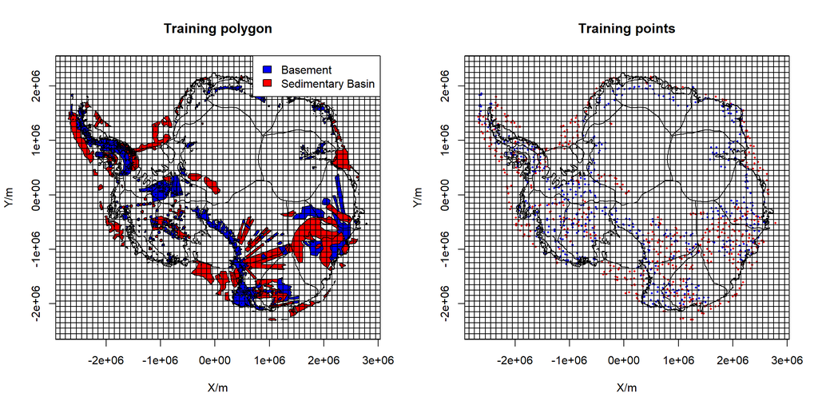

```r
par(mfrow=c(1,2))    # set the plotting area into a 1*2 array

plot(x=NULL,
      y=NULL,
      xlim=c(-2705000, 2815000),  ## with c()
      ylim=c(-2315000, 2215000),xlab="X/m", ylab="Y/m",main="Training polygon",
      asp=1)  ## with c()
plot(Train_Basement,add=T,col="blue")
plot(Train_SSB,add=T,col="red")
plot(Basins_IMBIE,add=T)
plot(Coastline,add=T)

plot(fishgrid,add=T)
legend("topright",
       legend = c('Basement', 'Sedimentary Basin'),
       fill = c("blue","red"),       # Color of the squares
       border = "black") # Color of the border of the squares

plot(x=NULL,
      y=NULL,
      xlim=c(-2705000, 2815000),  ## with c()
      ylim=c(-2315000, 2215000),xlab="X/m", ylab="Y/m",main="Training points",
      asp=1)  ## with c()

plot(TP_example[TP_example@data[["Label"]]==1,],col="red",pch=16,add=T,cex=0.4)
plot(TP_example[TP_example@data[["Label"]]==0,],col="blue",pch=16,add=T,cex=0.4)

plot(Basins_IMBIE,add=T)
plot(Coastline,add=T)

plot(fishgrid,add=T)
```

## Sensitivity test for Roughness and data density

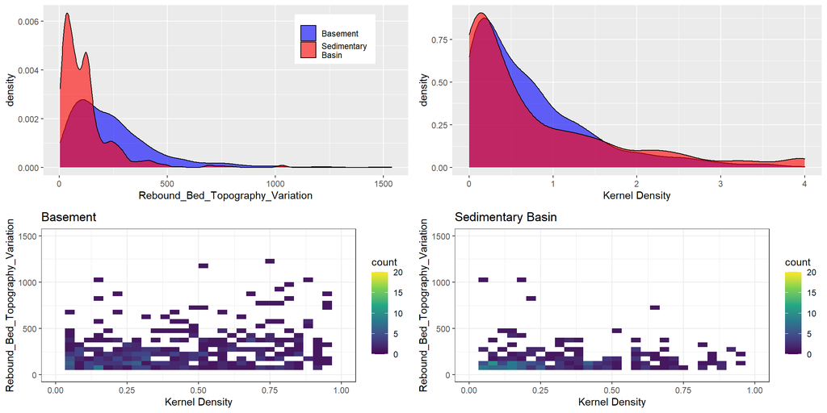

```r
Kernel <- raster(".\\Plot_data\\Kernel_BM_2_N.tif")


sdata <- data.frame(TP_example,extract(Kernel,TP_example))


sdata$Label <- as.factor(sdata$Label)


col.pal <- c("blue","red")

sdata_0 <- subset(sdata, Label == 0 )
sdata_1 <- subset(sdata, Label == 1 )

p1<-ggplot(sdata, aes(x= sdata[,length(fs)],fill=Label)) +
          geom_density(position="identity", alpha=0.6)+
          scale_fill_manual(labels = c("Basement", "Sedimentary\nBasin"),values = col.pal) +
          scale_x_continuous(name = "Rebound_Bed_Topography_Variation")+
          theme(legend.position = c(0.8, 0.8),legend.title = element_blank())

p2<-ggplot(sdata, aes(x= sdata[,length(fs)+5],fill=Label)) +
          geom_density(position="identity", alpha=0.6)+
          scale_fill_manual(labels = c("Basement", "Sedimentary\nBasin"),values = col.pal) +
          scale_x_continuous(name = "Kernel Density")+
          theme(legend.position='none')

p3<-ggplot(sdata_0) +
  aes(x = extract.Kernel..TP_example., y = Rebound_Bed_Topography_Variation) +
  geom_bin2d() +
  scale_fill_continuous(type = "viridis",limits = c(0, 20)) +
  theme_bw() +
    xlim(0, 1) +
  ylim(0, 1500) +
  labs(title = "Basement",x = "Kernel Density", y="Rebound_Bed_Topography_Variation")


p4<-ggplot(sdata_1) +
  aes(x = extract.Kernel..TP_example., y = Rebound_Bed_Topography_Variation) +
  geom_bin2d() +
  scale_fill_continuous(type = "viridis",limits = c(0, 20)) +
  theme_bw()+
  xlim(0, 1) +
  ylim(0, 1500) +
  labs(title = "Sedimentary Basin",x = "Kernel Density", y="Rebound_Bed_Topography_Variation")
ggarrange(p1, p2, p3, p4, ncol = 2,nrow = 2)
```

Calculate the corrolation between data density and roughness

```r
# Load data


sdata_0 <- subset(sdata, Label == 0 )
sdata_1 <- subset(sdata, Label == 1 )


x <- sdata[,c(length(fs),length(fs)+5)]
x0 <- sdata[,c(length(fs),length(fs)+5)]
x1 <- sdata[,c(length(fs),length(fs)+5)]

x <- na.omit(x) #drop nan value
x0 <- na.omit(x0) #drop nan value
x1 <- na.omit(x1) #drop nan value

Matrix_x <- matrix(unlist(x), ncol = 2, nrow = length(TP_example))
Matrix_x0 <- matrix(unlist(x0), ncol = 2, nrow = length(TP_example)/2)
Matrix_x1 <- matrix(unlist(x1), ncol = 2, nrow = length(TP_example)/2)

Matrix_x <- na.omit(Matrix_x)
Matrix_x0 <- na.omit(Matrix_x0)
Matrix_x1 <- na.omit(Matrix_x1)

M <- mine(Matrix_x,alpha=0.7)
M0 <- mine(Matrix_x0,alpha=0.7)
M1 <- mine(Matrix_x1,alpha=0.7)

corR <- M$MIC
corR0 <- M0$MIC
corR1 <- M1$MIC

rownames(corR) <- colnames(x)
colnames(corR) <- colnames(x)


print(corR)
```

```
                                 Rebound_Bed_Topography_Variation
Rebound_Bed_Topography_Variation                        0.9999994
extract.Kernel..TP_example.                             0.3010769
                                 extract.Kernel..TP_example.
Rebound_Bed_Topography_Variation                   0.3010769
extract.Kernel..TP_example.                        1.0000000
```

```r
print(corR0)
```

```
          [,1]      [,2]
[1,] 1.0000000 0.2734895
[2,] 0.2734895 1.0000000
```

```r
print(corR1)
```

```
          [,1]      [,2]
[1,] 1.0000000 0.2734895
[2,] 0.2734895 1.0000000
```

## Input feature selection

### Boruta for input feature importance

```r
TP_example_ngeo <- st_as_sf(TP_example)
TP_example_ngeo <- st_set_geometry(TP_example_ngeo, NULL) #remove geometry

TP_example_ngeo <- na.omit(TP_example_ngeo)

par(mar=c(10,5,2,2))
B1 <- Boruta(as.factor(Label)~., data = TP_example_ngeo, pValue=0.5, maxRuns=500)


print(B1)
```

```
Boruta performed 6 iterations in 9.018933 secs.
 24 attributes confirmed important: Basal_Friction,
Crust_Thickness_ANTCRUST, Curie_Depth, Gravity_ANTGG_BG,
Gravity_ANTGG_BG_HP1000 and 19 more;
 No attributes deemed unimportant.
```

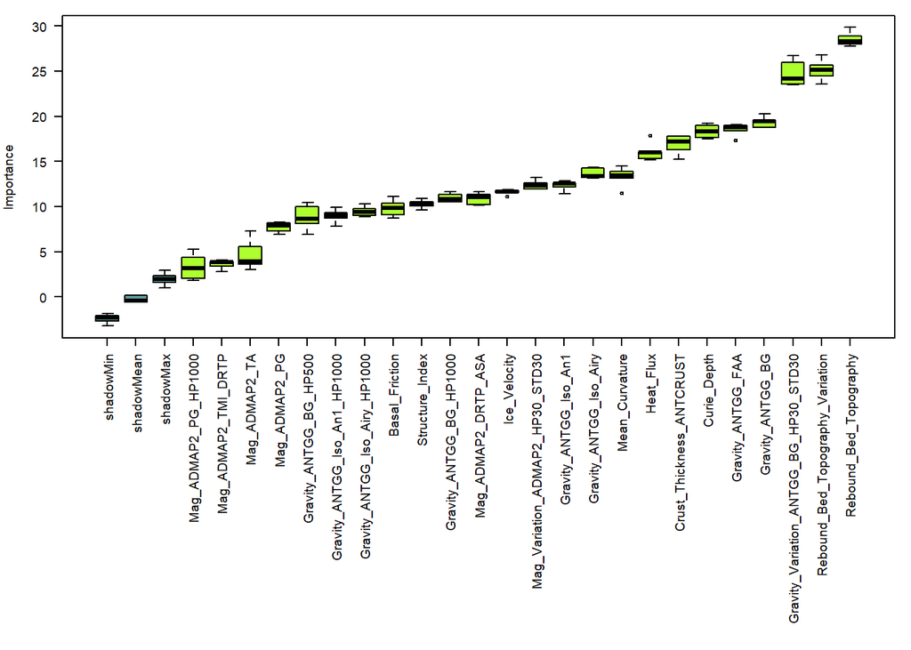

```r
par(mar=c(20,4,1,1), cex = 0.6)

plot(B1, las=2, colCode = c("greenyellow", "yellow2", "red3", "cadetblue"), xlab = "")
```

```r
BorImp <- attStats(B1)[,c(1,6)]
BorImp <- subset(BorImp, decision == "Confirmed")
BorImp$Var <- rownames(BorImp)
rownames(BorImp) <- NULL
BorList <- list(BorImp[order(BorImp[1],decreasing=T),c(3,1)])

BorList
```

```
[[1]]
                                     Var   meanImp
22                Rebound_Bed_Topography 28.500917
23      Rebound_Bed_Topography_Variation 25.113891
12 Gravity_Variation_ANTGG_BG_HP30_STD30 24.688442
4                       Gravity_ANTGG_BG 19.392272
7                      Gravity_ANTGG_FAA 18.557953
3                            Curie_Depth 18.327311
2               Crust_Thickness_ANTCRUST 16.907824
13                             Heat_Flux 16.062146
8                 Gravity_ANTGG_Iso_Airy 13.617182
21                        Mean_Curvature 13.324732
20       Mag_Variation_ADMAP2_HP30_STD30 12.384674
10                 Gravity_ANTGG_Iso_An1 12.343810
14                          Ice_Velocity 11.600737
5                Gravity_ANTGG_BG_HP1000 10.947306
15                   Mag_ADMAP2_DRTP_ASA 10.909736
24                       Structure_Index 10.291051
1                         Basal_Friction  9.811842
9          Gravity_ANTGG_Iso_Airy_HP1000  9.453094
11          Gravity_ANTGG_Iso_An1_HP1000  8.961355
6                 Gravity_ANTGG_BG_HP500  8.771231
16                         Mag_ADMAP2_PG  7.756739
18                         Mag_ADMAP2_TA  4.535077
19                   Mag_ADMAP2_TMI_DRTP  3.639055
17                  Mag_ADMAP2_PG_HP1000  3.310422
```

### Calculate MIC correlation

```r
# Load data

TP_example_2 <- TP_example[, BorList[[1]][[1]]]

TB_drio <- na.omit(TP_example_2) #drop nan value

x <- TB_drio

XX <- st_as_sf(x)

XX <- st_set_geometry(XX, NULL) #remove geometry

Matrix_x <- matrix(unlist(XX), ncol = length(BorList[[1]][[1]]), nrow = length(TP_example))

Matrix_x <- na.omit(Matrix_x)

M2 <- mine(Matrix_x,alpha=0.7)

corR2 <- M2$MIC

rownames(corR2) <- colnames(XX)

colnames(corR2) <- colnames(XX)
```

### Selected Input feature

Relationship of RF out of bag score vs MIC correlation

```r
seed <- 222

df_total <- data.frame()

for (i in c(10:100)*0.01) {
r <- i

cr <- corR2

for(j in 1:length(cr[1,])){
  if (j == 1){
    pl <- c(names(cr[j,][1]),names( cr[j,][sqrt((cr[j,])^2)<r]))
    pl1 <- pl
  } else if (names(cr[j,])[j] %in% pl1){
    rem <- names(cr[j,-c(1:j)][sqrt((cr[j,-c(1:j)])^2)>r])
    if (length(rem) != 0L){
      pl <- pl[!pl %in% rem]
    }
  }
  next
}

clms <- c(names(TP_example_ngeo[1]),pl)
seldata <- TP_example_ngeo[clms]

set.seed(seed)
seldata$Label = factor(seldata$Label)
fit <- randomForest(Label ~ ., data=seldata)
df <- data.frame(i, length(pl), fit$err.rate[nrow(fit$err.rate),1])
df_total <- rbind(df_total,df)
}

names(df_total)[2] <- "Npreds"
names(df_total)[3] <- "OOBerror"

max(df_total$OOBerror) - min(df_total$OOBerror)
```

```
[1] 0.171875
```

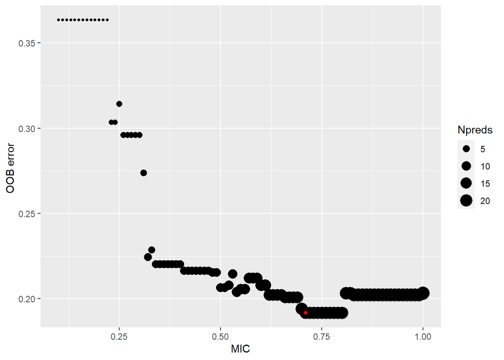

```r
ggplot(df_total,aes(i,OOBerror)) + geom_point(aes(size=Npreds)) +
  xlab("MIC") + ylab("OOB error ") +geom_point(aes(x=df_total[df_total[,3] == min(df_total[,3]), "i"][1],y=min(df_total[,3])),colour="red")
```

###Selected input feature with MIC value

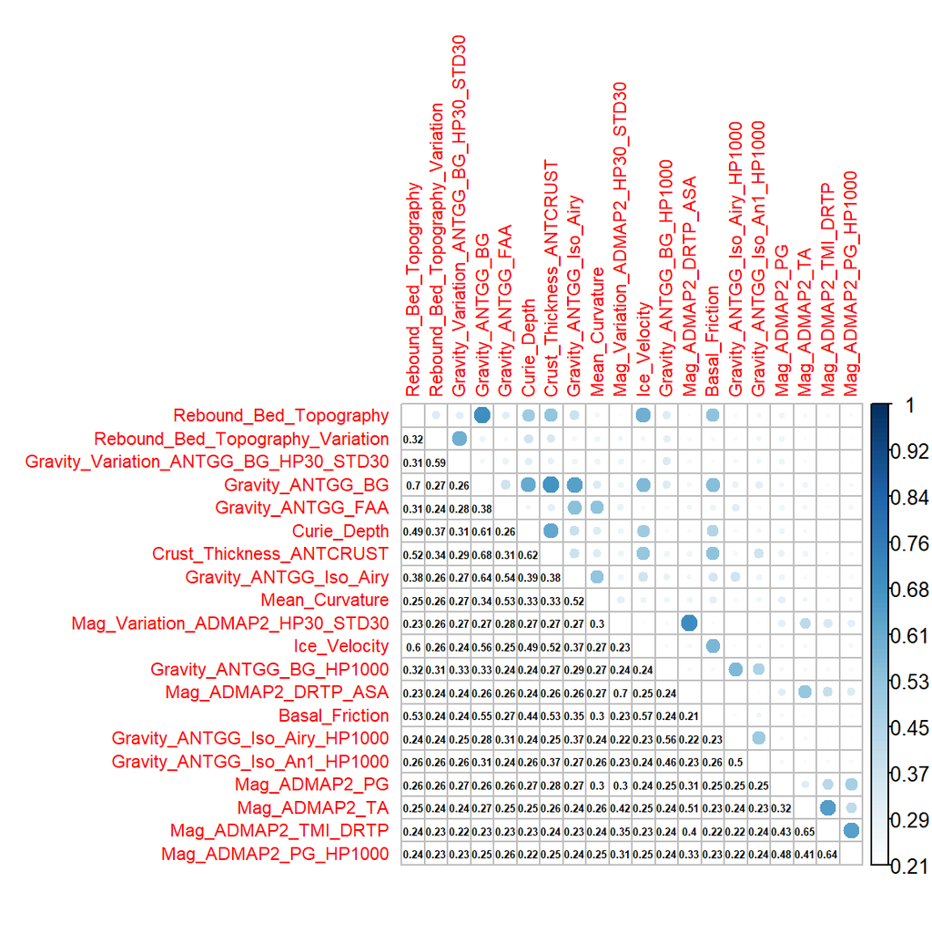

```r
r <- df_total[df_total[,3] == min(df_total[,3]), "i"][1]

cr <- corR2

for(j in 1:length(cr[1,])){
  if (j == 1){
    pl <- c(names(cr[j,][1]),names( cr[j,][sqrt((cr[j,])^2)<r]))
    pl1 <- pl
  } else if (names(cr[j,])[j] %in% pl1){
    rem <- names(cr[j,-c(1:j)][sqrt((cr[j,-c(1:j)])^2)>r])
    if (length(rem) != 0L){
      pl <- pl[!pl %in% rem]
    }
  }
  next
}

Npreds <- nrow(as.data.frame(pl))
clms <- c(names(TP_example_ngeo[1]),pl)
seldata <- TP_example_ngeo[clms]
sel.preds <- subset(Predp.stark,pl)


corrplot.mixed(corR2[pl,pl], lower.col =  "black", tl.pos = "l", tl.cex=0.7,number.cex = 0.4,is.corr = FALSE)
```

## RF parameyer turning

```
[1] TRUE
```

```
      mtry       Accuracy          ntree
 Min.   : 2   Min.   :0.7837   Min.   : 400
 1st Qu.: 6   1st Qu.:0.7890   1st Qu.: 500
 Median :11   Median :0.7914   Median : 700
 Mean   :11   Mean   :0.7928   Mean   : 700
 3rd Qu.:16   3rd Qu.:0.7976   3rd Qu.: 900
 Max.   :20   Max.   :0.8040   Max.   :1000
```

Plot the Model accuracy with ntree and mtry

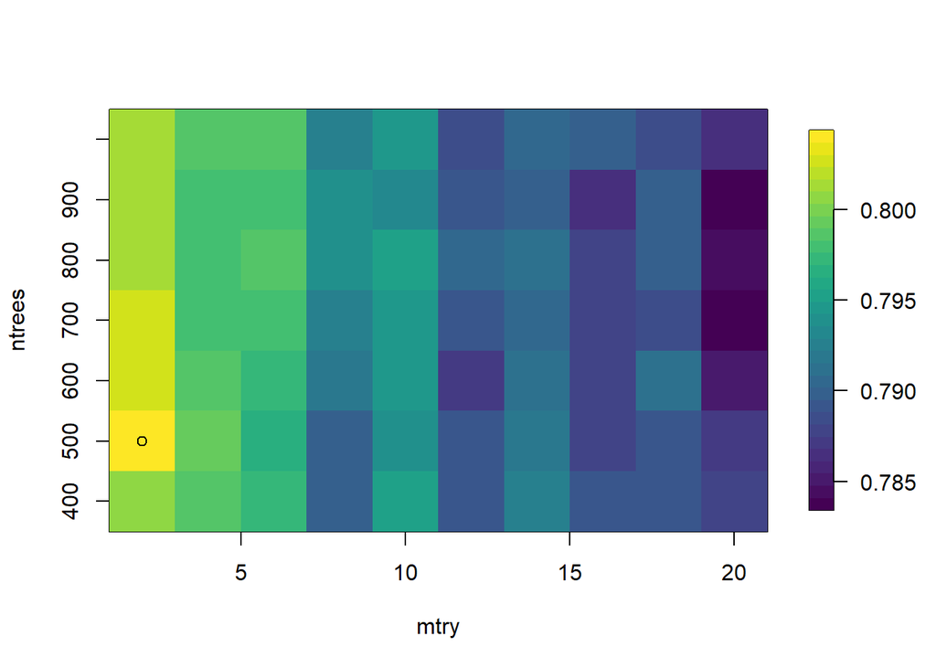

```r
mtry <- c(seq(2, length(clms)-1, by = 2))

ntrees <- c(seq(400, 1000, by = 100))

aa <- matrix(unlist(store_acc$Accuracy), ncol = 7, nrow = length(mtry))


image.plot(mtry,ntrees,aa,col=viridis(31))

mtry_f=which(aa == max(aa), arr.ind = TRUE)[1,1]*2

ntrees_f=400+(which(aa == max(aa), arr.ind = TRUE)[1,2]-1)*100

points(mtry_f,ntrees_f)
```

# Build RF model

## Model Result

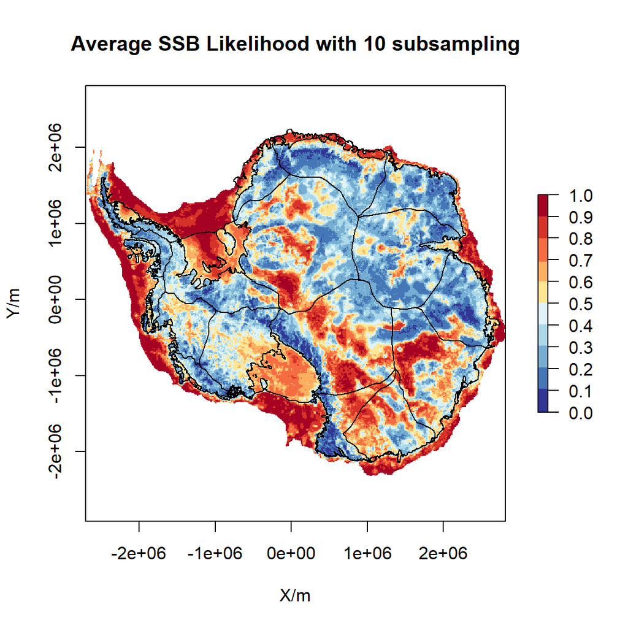

```r
mycols <- colors()[c(44,62,29,30,261,137,94,93,76,653)]

scolor <- c("#313694","#4576B6","#76ADD2","#AAD8E9","#DFF3F8","#FFE692","#FDAF60","#F66C42","#D73227","#A60324")

SSB_Probalility <- SSB_Probalility_Fishnet


aver_ppb<- sum(SSB_Probalility$Probalility)/10


plot(aver_ppb, col=scolor, breaks = c(0,0.1,0.2,0.3,0.4,0.5,0.6,0.7,0.8,0.9,1),xlab="X/m", ylab="Y/m", asp=1,main = "Average SSB Likelihood with 10 subsampling" )
plot(Basins_IMBIE,add=T)
plot(Coastline,add=T)
```

Write raster

## Importance of Input feature

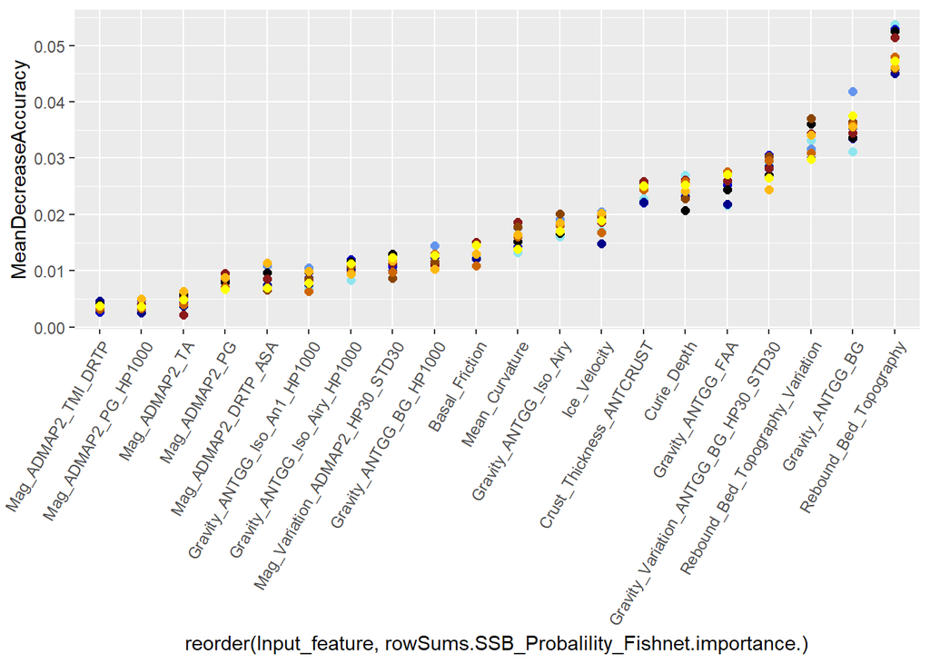

```r
Input_feature <- row.names(SSB_Probalility_Fishnet$importance)

Im <- data.frame(SSB_Probalility_Fishnet$importance,rowSums(SSB_Probalility_Fishnet$importance))

col=colors()[c(44,62,29,30,261,137,94,93,76,653)]

ggplot(Im,aes(reorder(Input_feature,rowSums.SSB_Probalility_Fishnet.importance.))) +
geom_point(aes(y=MeanDecreaseAccuracy),colour = col[1],size = 2) +
geom_point(aes(y=MeanDecreaseAccuracy.1),colour = col[2],size = 2) +
geom_point(aes(y=MeanDecreaseAccuracy.2),colour = col[3],size = 2) +
geom_point(aes(y=MeanDecreaseAccuracy.3),colour = col[4],size = 2) +
geom_point(aes(y=MeanDecreaseAccuracy.4),colour = col[5],size = 2) +
geom_point(aes(y=MeanDecreaseAccuracy.5),colour = col[6],size = 2) +
geom_point(aes(y=MeanDecreaseAccuracy.6),colour = col[7],size = 2) +
geom_point(aes(y=MeanDecreaseAccuracy.7),colour = col[8],size = 2) +
geom_point(aes(y=MeanDecreaseAccuracy.8),colour = col[9],size = 2) +
geom_point(aes(y=MeanDecreaseAccuracy.9),colour = col[10],size = 2) +

theme(axis.text.x=element_text(angle=60,hjust=1,vjust=1))
```

## Model Performance and uncertainty

### Confusion matrix in each RF model

```r
Bcv.all_s <- SSB_Probalility_Fishnet$blockCV

acc_s <- confusionMatrix(Bcv.all_s$pred,as.factor(Bcv.all_s$Label))


print(acc_s)
```

```
Confusion Matrix and Statistics

          Reference
Prediction Basement  SSB
  Basement     4925 1537
  SSB          1155 4538

               Accuracy : 0.7785
                 95% CI : (0.771, 0.7859)
    No Information Rate : 0.5002
    P-Value [Acc > NIR] : < 2.2e-16

                  Kappa : 0.557

 Mcnemar's Test P-Value : 2.085e-13

            Sensitivity : 0.8100
            Specificity : 0.7470
         Pos Pred Value : 0.7621
         Neg Pred Value : 0.7971
             Prevalence : 0.5002
         Detection Rate : 0.4052
   Detection Prevalence : 0.5316
      Balanced Accuracy : 0.7785

       'Positive' Class : Basement
```

### Confusion matrix for use all training points

```r
TP_10 <- SSB_Probalility_Fishnet$TP

TP_ALL <- TP_10[1:3]

for (i in 2:10) {

TP_sub_sample <- TP_10[c(3*(i-1)+1):c(3*i)]

colnames(TP_sub_sample)[c(1,2,3)] <- c("Label", "x","y")

TP_ALL <- rbind(TP_ALL,TP_sub_sample)

}

sdata_cv <- data.frame(TP_ALL[,2:3],extract(sel.preds,TP_ALL[,2:3]))

sdata_cv<-cbind(TP_ALL[1], sdata_cv)

names(sdata_cv)[2] <- "x"

names(sdata_cv)[3] <- "y"

TP <- st_as_sf(sdata_cv, coords = c("x", "y"), crs = 3031)

TP.s <- as(TP, "Spatial")

tp_ngeo <- st_set_geometry(TP, NULL) #remove geometry


#Perform Block Cross Validation
block.C2 <- spatialBlock(speciesData = TP.s, # sf or SpatialPoints
                   species = "Label", # the response column (binomial or multi-class)
                   rows = 10,
                   cols = 10,
                   k = 10, # number of folds
                   selection = "random")
```

```
The best folds was in iteration 36:
   train_0 train_1 test_0 test_1
1     5527    5450    553    629
2     5569    5434    511    645
3     5505    5676    575    403
4     5410    5392    670    687
5     5273    5207    807    872
6     5329    5363    751    716
7     5593    5475    487    604
8     5491    5651    589    428
9     5579    5512    501    567
10    5444    5551    636    528
```

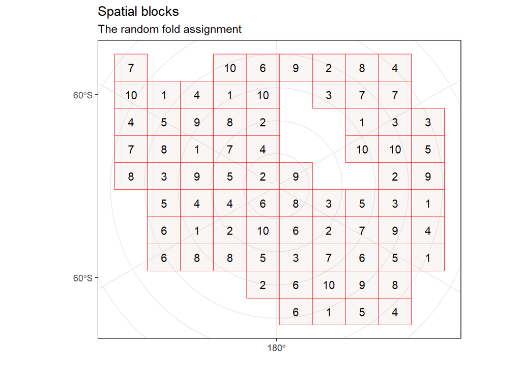

```r
folds <- block.C2$folds

Nclasses <- c(2L)

class <- c("0","1")

classes <- c("Basement","SSB")

# create a data.frame to store the prediction of each fold (record)

testTable <- tp_ngeo
testTable$pred <- NA

t <- data.frame()

for(k in seq_len(length(folds))){

  # extracting the training and testing indices
  # this way works with folds list (but not foldID)
  trainSet <- unlist(folds[[k]][1]) # training set indices

  testSet <- unlist(folds[[k]][2]) # testing set indices

  sub_train <- tp_ngeo[trainSet, ]

  sub_train$Label <- as.factor(sub_train$Label)

  sub_test <- tp_ngeo[testSet, ]

  nnmin <- min(table(sub_train[1]))

  rf <- randomForest(Label~., data=sub_train, replace = T, mtry=mtry_f, ntree=ntrees_f, na.action = na.roughfix) # model fitting on training set

  pred <- predict(rf, sub_test, type = "response",na.action = na.roughfix) # predict the test set

  t <- rbind(t, data.frame(sub_test[1], pred, sdata_cv[testSet,2:3]))

}


acc <- confusionMatrix(t$pred,as.factor(t$Label))

name <- paste("T", k, sep = "")

tmp <- list(conf=acc)

bcv.acc <- tmp

bcv.acc
```

```
$conf
Confusion Matrix and Statistics

          Reference
Prediction    0    1
         0 5039 1435
         1 1041 4644

               Accuracy : 0.7964
                 95% CI : (0.7891, 0.8035)
    No Information Rate : 0.5
    P-Value [Acc > NIR] : < 2.2e-16

                  Kappa : 0.5927

 Mcnemar's Test P-Value : 2.834e-15

            Sensitivity : 0.8288
            Specificity : 0.7639
         Pos Pred Value : 0.7783
         Neg Pred Value : 0.8169
             Prevalence : 0.5000
         Detection Rate : 0.4144
   Detection Prevalence : 0.5324
      Balanced Accuracy : 0.7964

       'Positive' Class : 0
```

### Misclassification during block-cv

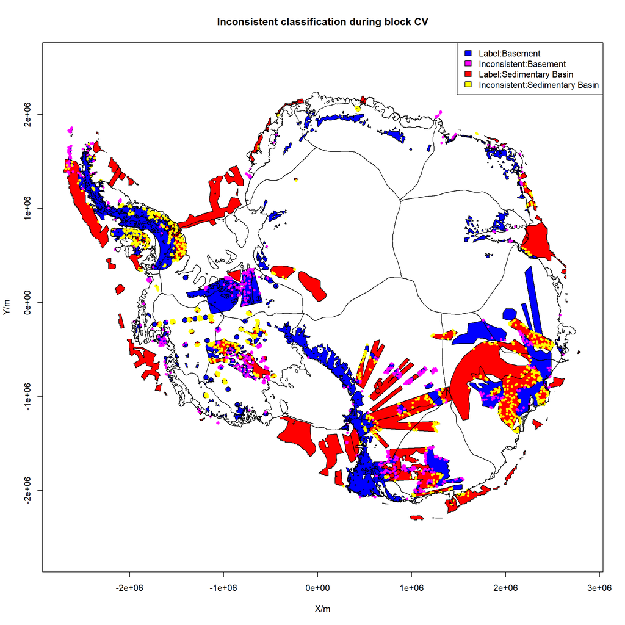

```r
Test.all <- data.frame(SSB_Probalility_Fishnet$blockCV)
Test.all$Res1[Test.all$Label == "SSB"] <- 1
Test.all$Res1[Test.all$Label == "Basement"] <- 0
Test.all$Res2[Test.all$pred == "SSB"] <- 1
Test.all$Res2[Test.all$pred == "Basement"] <- 0
Test.all$ResL <- Test.all$Res1 - Test.all$Res2

Test.all <- na.omit(Test.all)


Wrong_class <- st_as_sf(Test.all, coords = c("x", "y"), crs = 3031)

Wrong_class <- Wrong_class[5]

Wrong_class <-  subset(Wrong_class, ResL != 0)

Wrong_class <- as(Wrong_class, "Spatial")

plot(x=NULL,
      y=NULL,
      xlim=c(-2705000, 2815000),  ## with c()
      ylim=c(-2315000, 2215000),xlab="X/m", ylab="Y/m",main="Inconsistent classification during block CV",
      asp=1)  ## with c()



plot(Train_Basement,add=T,col="blue")
plot(Train_SSB,add=T,col="red")
plot(Basins_IMBIE,add=T)


points(Wrong_class[Wrong_class$ResL==-1,], pch = 16, col="magenta",cex = 0.6)

points(Wrong_class[Wrong_class$ResL==1,], pch = 16, col="yellow",cex = 0.6)

legend("topright",
       legend = c('Label:Basement', 'Inconsistent:Basement', 'Label:Sedimentary Basin', 'Inconsistent:Sedimentary Basin'),
       fill = c("blue","magenta","red","yellow"),       # Color of the squares
       border = "black") # Color of the border of the squares

plot(Coastline,add=T)
```

### Model result vs initial training polygon

```r
Train_compare <- raster('.\\Plot_data\\SSB_Clean_Ini.tif')


Train_compare <- reclassify(Train_compare, c(1.1,11,0))



respond_1 <- reclassify(aver_ppb, c(0,0.4999,0,  0.5,1,1))


differ_respond=respond_1-Train_compare
print(freq(differ_respond))
```

```
Frequencies
differ_respond
Type: Numeric

                Freq   % Valid   % Valid Cum.   % Total   % Total Cum.
----------- -------- --------- -------------- --------- --------------
         -1     2451      6.69           6.69      0.98           0.98
       -0.5        2      0.01           6.70      0.00           0.98
          0    33089     90.38          97.08     13.23          14.21
        0.5        3      0.01          97.09      0.00          14.21
          1     1065      2.91         100.00      0.43          14.64
       <NA>   213446                              85.36         100.00
      Total   250056    100.00         100.00    100.00         100.00
```

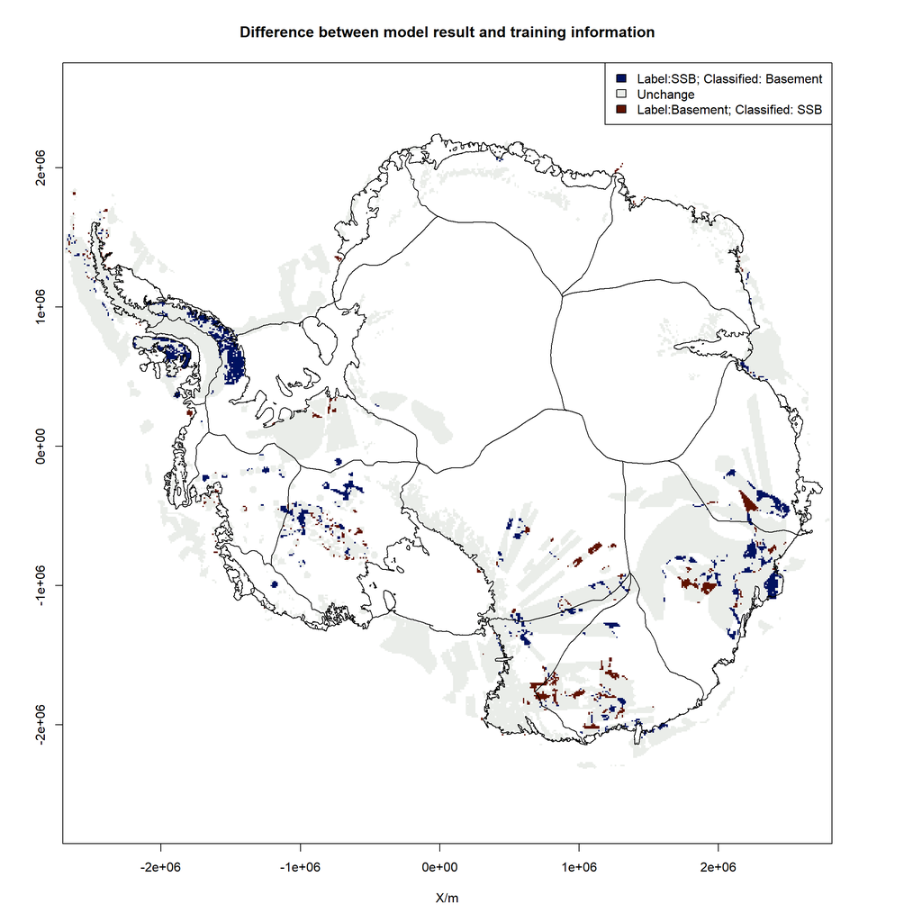

```r
plot(differ_respond, col=scico(3, palette = 'vik'), xlab="X/m",  asp=1, main = "Difference between model result and training information",legend=FALSE )
plot(Basins_IMBIE,add=T)

plot(Coastline,add=T)

legend("topright",
       legend = c('Label:SSB; Classified: Basement ', 'Unchange','Label:Basement; Classified: SSB ' ),
       fill = c(scico(3, palette = 'vik')),       # Color of the squares
       border = "black") # Color of the border of the squares
```

### Likelihood variation

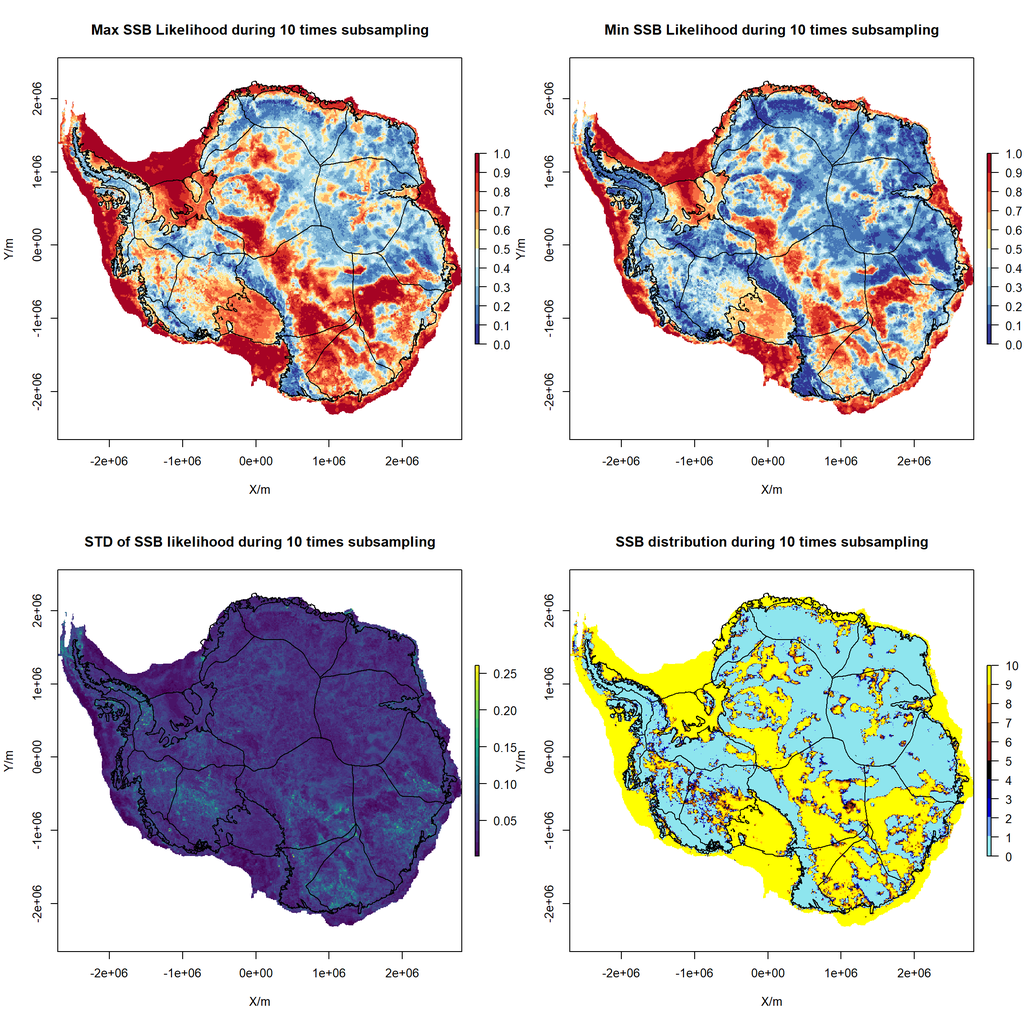

```r
par(mfrow=c(2,2))    # set the plotting area into a 1*2 array
mycols <- colors()[c(44,62,29,30,261,137,94,93,76,653)]

scolor <- c("#313694","#4576B6","#76ADD2","#AAD8E9","#DFF3F8","#FFE692","#FDAF60","#F66C42","#D73227","#A60324")

SSB_Probalility <- SSB_Probalility_Fishnet

max_1 <- max(SSB_Probalility$Probalility)
min_1 <- min(SSB_Probalility$Probalility)
std_1 <- calc(SSB_Probalility$Probalility, sd)
reso_1 <- sum(SSB_Probalility$fress)


plot(max_1, col=scolor, breaks = c(0,0.1,0.2,0.3,0.4,0.5,0.6,0.7,0.8,0.9,1),xlab="X/m", ylab="Y/m", asp=1,main = "Max SSB Likelihood during 10 times subsampling" )
plot(Basins_IMBIE,add=T)
plot(Coastline,add=T)

plot(min_1, col=scolor, breaks = c(0,0.1,0.2,0.3,0.4,0.5,0.6,0.7,0.8,0.9,1),xlab="X/m", ylab="Y/m", asp=1, main = "Min SSB Likelihood during 10 times subsampling" )
plot(Basins_IMBIE,add=T)
plot(Coastline,add=T)


plot(std_1, col=viridis(21),xlab="X/m", ylab="Y/m", asp=1, main = "STD of SSB likelihood during 10 times subsampling" )
plot(Basins_IMBIE,add=T)
plot(Coastline,add=T)


plot(reso_1, col=mycols,breaks = c(0,1,2,3,4,5,6,7,8,9,10),xlab="X/m", ylab="Y/m", asp=1, main = "SSB distribution during 10 times subsampling" )
plot(Basins_IMBIE,add=T)
plot(Coastline,add=T)
```

Write STD to tif

### Misclassification vs STD of subRF model

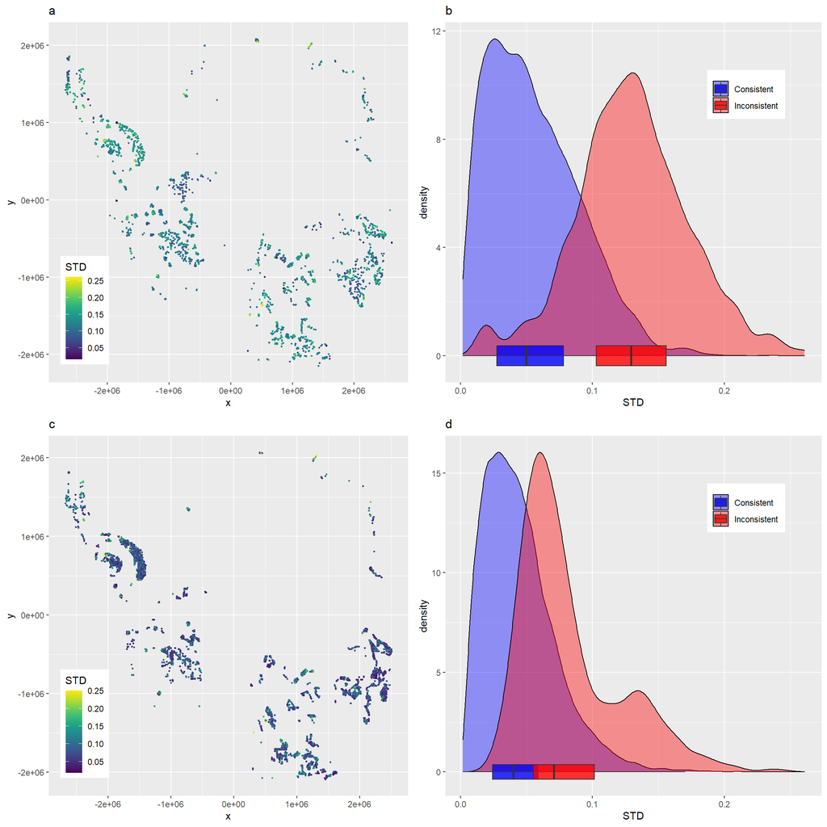

```r
Test.all <- data.frame(SSB_Probalility_Fishnet$blockCV)
Test.all$Res1[Test.all$Label == "SSB"] <- 1
Test.all$Res1[Test.all$Label == "Basement"] <- 0
Test.all$Res2[Test.all$pred == "SSB"] <- 1
Test.all$Res2[Test.all$pred == "Basement"] <- 0
Test.all$ResL <- Test.all$Res1 - Test.all$Res2

Test.all <- na.omit(Test.all)


Wrong_class <- st_as_sf(Test.all, coords = c("x", "y"), crs = 3031)

Wrong_class <- Wrong_class[5]

Wrong_class <- as(Wrong_class, "Spatial")

STD_P <- Wrong_class

sdata <- data.frame(STD_P,extract(std_1,STD_P))

names(sdata) <- c("Respond","x","y","o","STD")



sdata$Respond[abs(sdata$Respond)<0.5] <- 0

sdata$Respond[abs(sdata$Respond)>=0.5] <- 1


sdata$Respond <- as.factor(sdata$Respond)

sdata_1 <-  subset(sdata,Respond == 1)

sdata_0 <-  subset(sdata,Respond == 0)



col.pal <- c("blue","red")


p1<- ggplot(sdata_1,aes(x, y, color=STD)) +
  geom_point(size = 0.5)+
  scale_colour_gradientn(colours=viridis(21))+
  theme(legend.position = c(0.1, 0.2))+
  labs(title = "a")

p2<-ggplot(sdata, aes(x= sdata[,5],fill=Respond)) +
          geom_density(position="identity", alpha=0.4)+
          geom_boxplot(position="identity", alpha=0.8,outlier.shape = NA) +
          scale_fill_manual(labels = c("Consistent", "Inconsistent"),values = col.pal) +
          scale_x_continuous(name = "STD")+
          theme(legend.position = c(0.8, 0.8),legend.title = element_blank())+
          labs(title = "b")


p <- rasterToPoints(differ_respond)
tpp <- data.frame(p)
p_select <- tpp

p_select$layer[abs(tpp$layer)<0.5] <- 0

p_select$layer[abs(tpp$layer)>=0.5] <- 1


p_select <- st_as_sf(p_select, coords = c("x", "y"), crs = 3031)

p_select <- as_Spatial(p_select)

ssdata <- data.frame(p_select,extract(std_1,p_select))

names(ssdata) <- c("Respond","x","y","o","STD")


ssdata$Respond <- as.factor(ssdata$Respond)

ssdata_1 <-  subset(ssdata,Respond == 1)


col.pal <- c("blue","red")


p3<- ggplot(ssdata_1,aes(x, y, color=STD)) +
  geom_point(size = 0.5)+
  scale_colour_gradientn(colours=viridis(21))+
  theme(legend.position = c(0.1, 0.2))+
  labs(title = "c")


p4<-ggplot(ssdata, aes(x= ssdata[,5],fill=Respond)) +
          geom_density(position="identity", alpha=0.4)+
          geom_boxplot(position="identity", alpha=0.8,outlier.shape = NA) +
          scale_fill_manual(labels = c("Consistent", "Inconsistent"),values = col.pal) +
          scale_x_continuous(name = "STD")+
          theme(legend.position = c(0.8, 0.8),legend.title = element_blank())+
          labs(title = "d")

ggarrange(p1, p2,p3,p4, ncol = 2,nrow = 2)
```

## Sensitivity test by shift reference fishnet

### Model Result

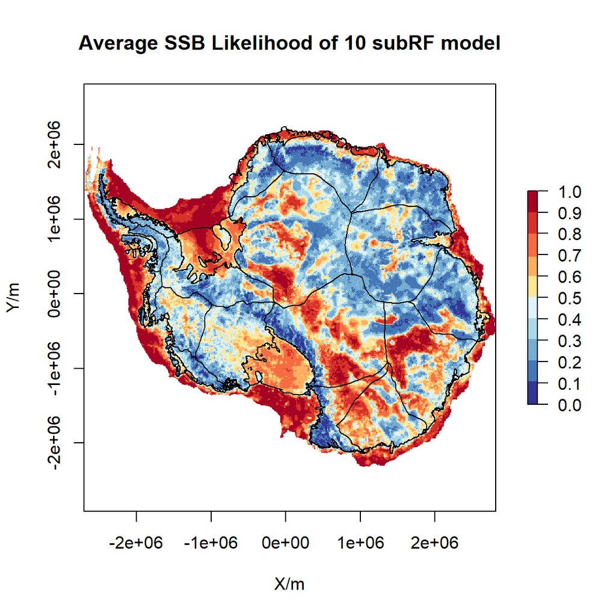

```r
mycols <- colors()[c(44,62,29,30,261,137,94,93,76,653)]

scolor <- c("#313694","#4576B6","#76ADD2","#AAD8E9","#DFF3F8","#FFE692","#FDAF60","#F66C42","#D73227","#A60324")

SSB_Probalility <- SSB_Probalility_Fishnet_shift


aver_ppb_s <- sum(SSB_Probalility$Probalility)/10


plot(aver_ppb, col=scolor, breaks = c(0,0.1,0.2,0.3,0.4,0.5,0.6,0.7,0.8,0.9,1),xlab="X/m", ylab="Y/m", asp=1,main = "Average SSB Likelihood of 10 subRF model" )
plot(Basins_IMBIE,add=T)
plot(Coastline,add=T)
```

###Plot difference of model result

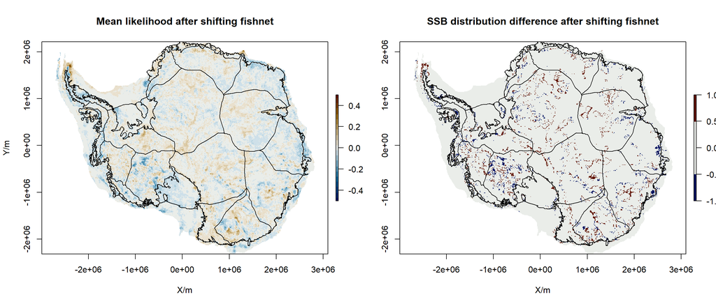

```r
differ_aver=aver_ppb-aver_ppb_s

respond_1 <- reclassify(aver_ppb, c(0,0.4999,0,  0.5,1,1))

respond_2 <- reclassify(aver_ppb_s, c(0,0.4999,0,  0.5,1,1))

differ_respond=respond_1-respond_2

par(mfrow=c(1,2))    # set the plotting area into a 1*2 array


plot(differ_aver, col=scico(21, palette = 'vik'), zlim = c(-0.5,0.5), xlab="X/m", ylab="Y/m", asp=1, main = "Mean likelihood after shifting fishnet" )

plot(Basins_IMBIE,add=T)

plot(Coastline,add=T)


plot(differ_respond, col=scico(3, palette = 'vik'), xlab="X/m",  asp=1, main = "SSB distribution difference after shifting fishnet" )

plot(Basins_IMBIE,add=T)

plot(Coastline,add=T)
```